# Homework Assignment 4

Clustering and Outlier Detection

Gunnar Sundberg - gsundberg3513@floridapoly.edu

Run the code below to lad the `tidyverse` package for data transformation and visualization, the `dbscan` package for clustering and outlier detection, and the `factoextra` package for quick visualizations of models (you are not required to use `factoextra` and can choose to use other methods for creating visualizations that explain your results when requested)

```r
library(tidyverse)
library(dbscan)
library(factoextra)
library(caret)
library(patchwork)
```

# Problem 1

Read the dataset on corporate data for 22 public utilities in the United States.

```r
utilities <- read_csv("https://github.com/reisanar/datasets/raw/master/Utilities.csv")
```

Sample entries:

```r
head(utilities)
```

| Company | Fixed_charge | RoR | Cost | Load_factor | Demand_growth | Sales | Nuclear | Fuel_Cost |
| --- | --- | --- | --- | --- | --- | --- | --- | --- |
| Arizona | 1.06 | 9.2 | 151 | 54.4 | 1.6 | 9077 | 0.0 | 0.628 |
| Boston | 0.89 | 10.3 | 202 | 57.9 | 2.2 | 5088 | 25.3 | 1.555 |
| Central | 1.43 | 15.4 | 113 | 53.0 | 3.4 | 9212 | 0.0 | 1.058 |
| Commonwealth | 1.02 | 11.2 | 168 | 56.0 | 0.3 | 6423 | 34.3 | 0.700 |
| NY | 1.49 | 8.8 | 192 | 51.2 | 1.0 | 3300 | 15.6 | 2.044 |
| Florida | 1.32 | 13.5 | 111 | 60.0 | -2.2 | 11127 | 22.5 | 1.241 |

| Variables | Description |
| --- | --- |
| `Company` | Company name |
| `Fixed_charge` | Fixed-charge coverage ratio (income/debt) |
| `RoR` | Percent rate of return on capital |
| `Cost` | Cost per KW capacity in place |
| `Load_factor` | Annual load factor |
| `Demand_growth` | Percent demand growth |
| `Sales` | Sales (KWH use per year) |
| `Nuclear` | Nuclear Percent nuclear |
| `Fuel_Cost` | Fuel_Cost Total fuel costs (cents per KWH) |

1. Considering the numerical attributes available, give an example where clustering analysis using this dataset would be useful for decision making or validation.
2. Create any data summary of the different attributes (or a subset of them).
3. Use hierarchical clustering using the numerical attributes (you can for example use single linkage here, i.e. `method = "single"` when using the `hclust()` function). Use the results from part (b) to decide if any pre-processing or data transformation is appropriate. Comment on your clustering results (for example, are there specific attributes that characterize the different groups)
4. Create a dendrogram representing the clustering found in part (c). Comment on your results.

## Solutions

1. Considering the interest in making changes to methods of energy production in the United States, a clustering analysis that shows a clear separation between utilities with higher percent nuclear and lower percent nuclear would be very useful for decision-making.
2. We will create a summary for all numeric variables:

```r
my_utilities <- utilities %>%
                select(!Company)

summary(my_utilities)
```

```
  Fixed_charge        RoR             Cost        Load_factor    Demand_growth        Sales          Nuclear
 Min.   :0.750   Min.   : 6.40   Min.   : 96.0   Min.   :49.80   Min.   :-2.200   Min.   : 3300   Min.   : 0.0
 1st Qu.:1.042   1st Qu.: 9.20   1st Qu.:148.5   1st Qu.:53.77   1st Qu.: 1.450   1st Qu.: 6458   1st Qu.: 0.0
 Median :1.110   Median :11.05   Median :170.5   Median :56.35   Median : 3.000   Median : 8024   Median : 0.0
 Mean   :1.114   Mean   :10.74   Mean   :168.2   Mean   :56.98   Mean   : 3.241   Mean   : 8914   Mean   :12.0
 3rd Qu.:1.190   3rd Qu.:12.35   3rd Qu.:195.8   3rd Qu.:60.30   3rd Qu.: 5.350   3rd Qu.:10128   3rd Qu.:24.6
 Max.   :1.490   Max.   :15.40   Max.   :252.0   Max.   :67.60   Max.   : 9.200   Max.   :17441   Max.   :50.2
   Fuel_Cost
 Min.   :0.309
 1st Qu.:0.630
 Median :0.960
 Mean   :1.103
 3rd Qu.:1.516
 Max.   :2.116
```

3. Based on the variation in scale shown in part (b), we will normalize our data before performing clustering:

```r
# calculate the pre-process parameters from the dataset
preprocessParams_norm <- preProcess(my_utilities, method = c("range"))
# transform the dataset using the parameters
utilities_norm <- predict(preprocessParams_norm, my_utilities)
# summarize the transformed dataset
summary(utilities_norm)
```

```
  Fixed_charge         RoR              Cost         Load_factor     Demand_growth        Sales
 Min.   :0.0000   Min.   :0.0000   Min.   :0.0000   Min.   :0.0000   Min.   :0.0000   Min.   :0.0000
 1st Qu.:0.3953   1st Qu.:0.3111   1st Qu.:0.3365   1st Qu.:0.2233   1st Qu.:0.3202   1st Qu.:0.2233
 Median :0.4865   Median :0.5167   Median :0.4776   Median :0.3680   Median :0.4561   Median :0.3341
 Mean   :0.4920   Mean   :0.4818   Mean   :0.4627   Mean   :0.4032   Mean   :0.4773   Mean   :0.3970
 3rd Qu.:0.5946   3rd Qu.:0.6611   3rd Qu.:0.6394   3rd Qu.:0.5899   3rd Qu.:0.6623   3rd Qu.:0.4829
 Max.   :1.0000   Max.   :1.0000   Max.   :1.0000   Max.   :1.0000   Max.   :1.0000   Max.   :1.0000
    Nuclear        Fuel_Cost
 Min.   :0.000   Min.   :0.0000
 1st Qu.:0.000   1st Qu.:0.1776
 Median :0.000   Median :0.3603
 Mean   :0.239   Mean   :0.4393
 3rd Qu.:0.490   3rd Qu.:0.6681
 Max.   :1.000   Max.   :1.0000
```

Now that our data has been normalized, we will examine hierarchical clustering with different types of linkage:

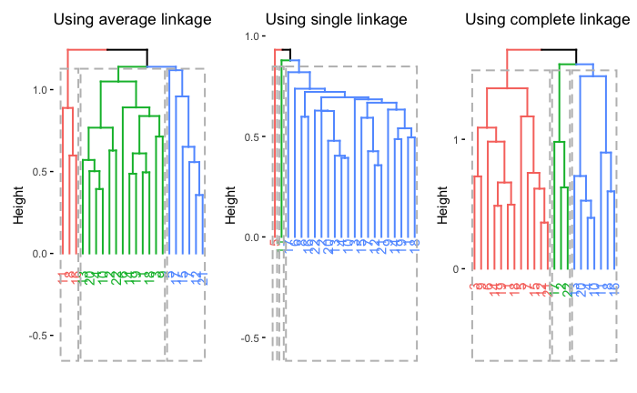

```r
hclusts <-
  tibble( # define the methods to try
    method = c("average",
               "single",
               "complete"))%>%
  mutate( # map method to hcut()
    myhclust = map(method,
                   ~factoextra::hcut(
                     utilities_norm,
                     hc_method = .x,
                     hc_func = "hclust",
                     k = 3 ))
         )

p1 <- factoextra::fviz_dend(
  hclusts$myhclust[[1]],
  rect = TRUE)+
  labs(title = paste0("Using ",
                      hclusts$method[1],
                      " linkage"))
p2 <- factoextra::fviz_dend(
  hclusts$myhclust[[2]],
  rect = TRUE)+
  labs(title = paste0("Using ",
                      hclusts$method[2],
                      " linkage"))
p3 <- factoextra::fviz_dend(
  hclusts$myhclust[[3]],
  rect = TRUE)+
  labs(title = paste0("Using ",
                      hclusts$method[3],
                      " linkage"))
(p1 + p2 + p3) +
  plot_layout(nrow = 1, widths = c(0.31, 0.31, 0.31))
```

We now examine the results of performing hierarchical clustering using multiple values of $k$ with average linkage:

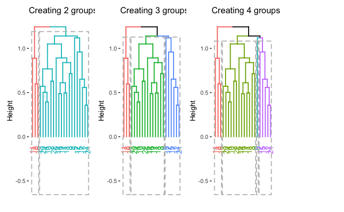

```r
#fviz_nbclust(my_utilities, hclust(method = "single"), method = "wss")

hclusts <-
  tibble( # define number of groups to test
    clusters = 2:4) %>%
    mutate( # map method to hcut()
      myhclust = map(clusters,
                     ~factoextra::hcut(
                        utilities_norm,
                        hc_method = "average",
                        hc_func = "hclust",
                        k = .x ))
    )

q1 <- factoextra::fviz_dend(
  hclusts$myhclust[[1]],
  rect = TRUE)+
  labs(title = paste0("Creating ",
                      hclusts$clusters[1],
                      " groups"))
q2 <- factoextra::fviz_dend(
  hclusts$myhclust[[2]],
  rect = TRUE)+
  labs(title = paste0("Creating ",
                      hclusts$clusters[2],
                      " groups"))
q3 <- factoextra::fviz_dend(
  hclusts$myhclust[[3]],
  rect = TRUE)+
  labs(title = paste0("Creating ",
                      hclusts$clusters[3],
                      " groups"))
(q1 + q2 + q3) +
  plot_layout(nrow = 1, widths = c(0.31, 0.31, 0.31, 0.31))
```

Based on the visualizations, we settle on $k=3$. We now perform hierarchical clustering:

```r
utilities_hcut <- hcut(utilities_norm, k = 3,
                 hc_method = "average",
                 hc_func = "hclust")

utilities_hcut
```

```
Call:
stats::hclust(d = x, method = hc_method)

Cluster method   : average
Distance         : euclidean
Number of objects: 22
```

Using the clusters we made, we now analyze the mean values for each feature, grouped by cluster, to get an idea of the feature values for each cluster:

```r
my_utilities %>%
  mutate(cluster = utilities_hcut$cluster) %>%
  group_by(cluster) %>%
  summarise(mean_Fixed_charge = mean(Fixed_charge), mean_RoR = mean(RoR), mean_Cost = mean(Cost), mean_Load_factor = mean(Load_factor), mean_Demand_growth = mean(Demand_growth), mean_Sales = mean(Sales), mean_Nuclear = mean(Nuclear), mean_Fuel_Cost = mean(Fuel_Cost))
```

| cluster | mean_Fixed_charge | mean_RoR | mean_Cost | mean_Load_factor | mean_Demand_growth | mean_Sales | mean_Nuclear | mean_Fuel_Cost |
| --- | --- | --- | --- | --- | --- | --- | --- | --- |
| 1 | 1.146154 | 11.930769 | 152.3846 | 55.62308 | 2.538462 | 8743.615 | 18.400000 | 0.8872308 |
| 2 | 1.100000 | 9.083333 | 174.8333 | 60.98333 | 3.216667 | 5988.000 | 4.133333 | 1.8381667 |
| 3 | 1.003333 | 8.866667 | 223.3333 | 54.83333 | 6.333333 | 15504.667 | 0.000000 | 0.5656667 |

The clusters show a clear separation in the percent nuclear, fuel cost, and sales, with some variations in other features as well. This result is especially interesting after the example given in part (a).

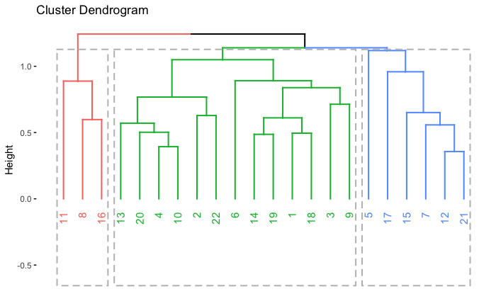

```r
fviz_dend(utilities_hcut, rect = TRUE)
```

# Problem 2

Read the dataset:

```r
spiral <- read_csv("https://github.com/reisanar/datasets/raw/master/spiral.csv")
# select only the first two columns
my_spiral <- select(spiral, 1:2)
```

Below is a plot of the dataset:

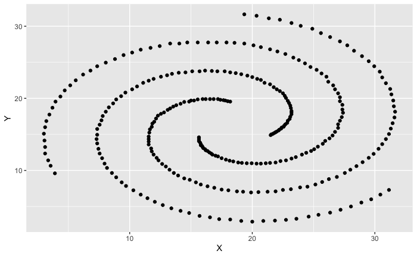

```r
ggplot(data = my_spiral) +
  geom_point(aes(x = X, y = Y))
```

1. Use any clustering method discussed in class to find 3 groups for this dataset.
2. Comment on your results from part (a)
3. Visualize the dataset again including the cluster assignments.

## Solutions

```r
spiral_dbscan <- dbscan(my_spiral, eps = 2.5, minPts = 5)
spiral_dbscan
```

```
DBSCAN clustering for 311 objects.
Parameters: eps = 2.5, minPts = 5
The clustering contains 3 cluster(s) and 0 noise points.

  1   2   3
105 101 105

Available fields: cluster, eps, minPts
```

2. I chose to use DBSCAN because there appear to be three separate groups in the data, but the points in the clusters are not similar in terms of Euclidean distance. Minimizing the within-cluster variation (K-means using Euclidean distance) would not make much sense in this situation. Using hierarchical clustering would lead to some of the same issues. DBSCAN is a great fit for this situation because there are three oddly-shaped clusters of dense points, with the density being similar for all of the clusters.

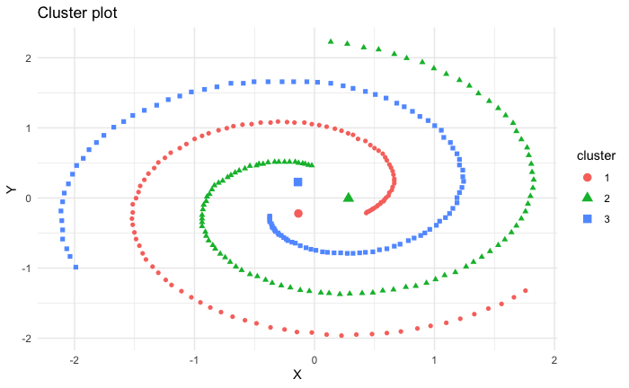

```r
fviz_cluster(spiral_dbscan, my_spiral,
             geom = "point", ellipse = F) +
  theme_minimal()
```

As shown by the plot, DBSCAN was very effective for this data.

# Problem 3

Search for one research article where “outlier detection” (or “anomaly detection”) has been used in a field/application of you interest. Share the name of the paper, a short description of the main results (check the abstract and conclusions of the paper), and a direct link to the work.

You could use the university’s library for this, or simply use [Google Scholar](https://scholar.google.com/scholar?hl=en&q=%22outlier+detection%22) for a list of the many papers that have used related techniques in recent years.

## Solutions

In [Outlier Detection for High Dimensional Data](http://www.facweb.iitkgp.ac.in/~shamik/autumn2012/dwdm/papers/Outlier%20Detection%20for%20High%20Dimensional%20Data.pdf) Aggarwal establishes a technique for outlier detection in high-dimensional data where traditional distance techniques do not necessarily apply. Distance-based methods struggle with the sparsity of high-dimensional data. Aggarwal’s method includes finding lower-dimensional projections which are locally sparse using an evolutionary search method that is nearly as effective as brute force, but at much lower cost. High-dimensional data has become of interest to me since encountering it many times in my research with Dr. Karaman. The author’s name also caught my eye from our discussion on the Apriori algorithm, but it turned out to be a different author.